# Reproducible Research: Peer Assessment 1

## Loading and preprocessing the data

Load the file **“activity.csv”**

As an illustration, we have staged the file in the working directory **“C:/Java/05_01_RMarkdowns”**

To execute the code chunk in your environment replace the above working directory with the correct directory as applicable.

**Note: This R Markdown file can be executed as is within RStudio after replacing the above working directory as mentioned**

```r
setwd("C:/Java/05_01_RMarkdowns")
activity <- read.table(file = "activity.csv", header = TRUE, sep = ",")
```

## What is mean total number of steps taken per day?

For this part of the assignment, you can ignore the missing values in the dataset.

1. Make a histogram of the total number of steps taken each day

   **We will use the barchart() function of the package lattice**

   Install the “lattice” library using the command (if not installed) : install.packages(“lattice”)

   Load the “lattice” library as we will use the barchart() function : library(lattice)

[figure not shown]

```r
library(lattice)
aggByDay <- setNames(aggregate(steps~as.Date(date), activity, sum, na.rm = TRUE), c("date","steps"))
xaxis <- seq(1, nrow(aggByDay), by = 6)
myScale <- list(x = list(rot = 45, cex = 1.0, labels = format(aggByDay$date, "%d-%b-%Y")[xaxis], at = xaxis))
barchart(date ~ steps, data = aggByDay,
    main = "No. of steps taken per day",
    ylab = "steps", xlab = "date", scales = myScale, horizontal = F)
```

2. Calculate and report the mean and median total number of steps taken per day

```r
paste("Mean of total number of steps taken per day:", mean(aggByDay$steps))
```

```
## [1] "Mean of total number of steps taken per day: 10766.1886792453"
```

```r
paste("Median of total number of steps taken per day:", median(aggByDay$steps))
```

```
## [1] "Median of total number of steps taken per day: 10765"
```

## What is the average daily activity pattern?

1. Make a time series plot (i.e. type = “l”) of the 5-minute interval (x-axis) and the average number of steps taken, averaged across all days (y-axis)

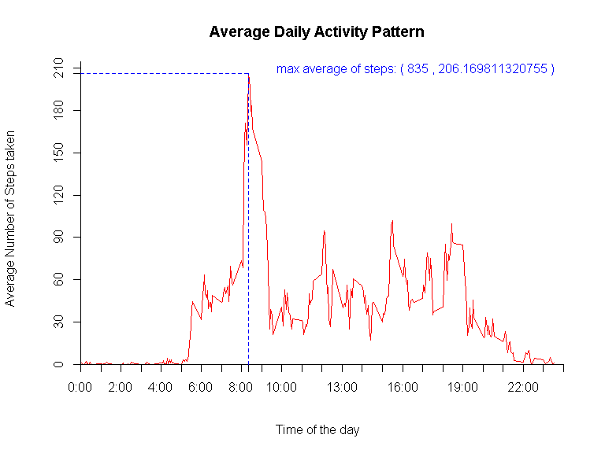

```r
timeSeriesData <- aggregate(steps ~ interval, data = activity, FUN = mean)
maxRecInd <- which.max(timeSeriesData$steps)
maxRec <-  timeSeriesData [maxRecInd, ]
maxInterval <- maxRec$interval
maxStep <- maxRec$steps


plot(timeSeriesData, type = "l", axes = F,
    xlab = "Time of the day",
    ylab = "Average Number of Steps taken",
    main = "Average Daily Activity Pattern",
    col = "red")

axis(1,at=c(seq(0,2400,100),maxInterval),
        label = paste(c(seq(0,24,1),8),c(rep(":00",25),":40"),sep=""), pos = 0)

axis(2,at=c(seq(0,240,30),maxStep),
        label = c(seq(0,240,30),maxStep), pos = 0)

noteStr <- paste("max average of steps: (",maxInterval,",",maxStep,")")
segments(maxInterval, 0, maxInterval, maxStep, col = "blue", lty = "dashed")
text(maxInterval,maxStep, noteStr, col = "blue", adj = c(-.1, -.1))
segments(0, maxStep, maxInterval, maxStep, col = "blue", lty = "dashed")
```

2. Which 5-minute interval, on average across all the days in the dataset, contains the maximum number of steps?

```r
paste("The 5-minute interval that contains the max number of steps:",maxInterval)
```

```
## [1] "The 5-minute interval that contains the max number of steps: 835"
```

```r
paste("The max number of steps taken:",maxStep)
```

```
## [1] "The max number of steps taken: 206.169811320755"
```